# Latihan 4 - Pembangkitan Proses MA(2), AR(2), dan ARMA(2,2)

Syarifah Nabila Jusman | M0401241038

16 September 2026

# 1 Pendahuluan

Latihan ini membangkitkan tiga proses deret waktu **MA(2)**, **AR(2)**, dan **ARMA(2,2)** masing-masing sebanyak 300 data. Setiap proses dibangkitkan dengan dua cara (manual melalui *loop* dan menggunakan `arima.sim()`), kemudian diperiksa kestasionerannya melalui plot time series, ACF, PACF, dan EACF, dilanjutkan dengan scatterplot antar lag serta perbandingan autokorelasi empirik terhadap autokorelasi teoritis.

Seluruh proses dibangun di atas *white noise* berikut:

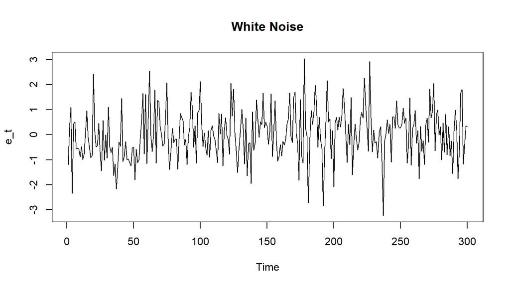

```r
n <- 300
set.seed(1234)
wn <- rnorm(n)

ts.plot(wn, main = "White Noise", ylab = "e_t")
```

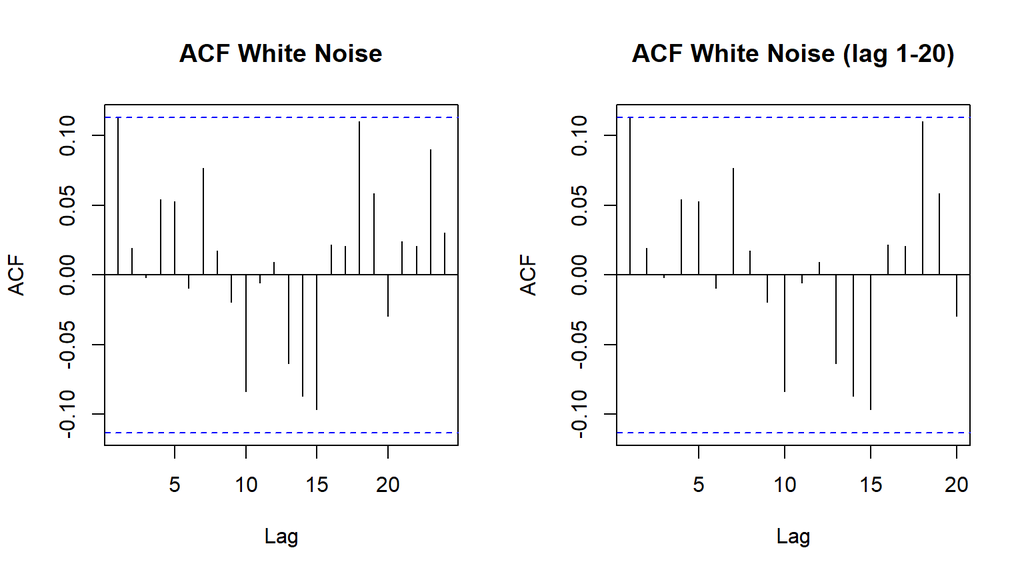

```r
par(mfrow = c(1, 2))
acf(wn, main = "ACF White Noise")
acf(wn, xlim = c(1, 20), main = "ACF White Noise (lag 1-20)")
```

```r
par(mfrow = c(1, 1))
```

Plot ACF di atas menunjukkan tidak ada autokorelasi yang signifikan pada white noise, sesuai dengan definisinya sebagai deretan nilai acak yang saling bebas.

# 2 Proses MA(2)

## 2.1 Landasan Teori

Proses MA(2) dituliskan sebagai:
$$Y_t = e_t + \theta_1 e_{t-1} + \theta_2 e_{t-2}$$

Untuk $\theta_1 = 0.4$ dan $\theta_2 = 0.6$, autokorelasi teoritisnya adalah:
$$\rho_1 = \frac{\theta_1+\theta_1\theta_2}{1+\theta_1^2+\theta_2^2},
\quad
\rho_2 = \frac{\theta_2}{1+\theta_1^2+\theta_2^2}, \quad
\rho_k = 0 \; \text{untuk } k \ge 3$$

Proses MA berorde hingga **selalu stasioner** dalam rataan dan ragam, apa pun nilai koefisiennya, sehingga tidak diperlukan pemeriksaan akar karakteristik seperti pada proses AR.

## 2.2 Pembangkitan Data

```r
theta1_ma <- 0.4
theta2_ma <- 0.6
```

### 2.2.1 Manual (loop)

```r
set.seed(1234)
wn_ma <- rnorm(n)

ma2_manual <- numeric(n)
ma2_manual[1:2] <- wn_ma[1:2]   # nilai awal
for (i in 3:n) {
  ma2_manual[i] <- wn_ma[i] + theta1_ma * wn_ma[i - 1] + theta2_ma * wn_ma[i - 2]
}
ma2_manual <- ts(ma2_manual)
```

### 2.2.2 Dengan `arima.sim()`

```r
set.seed(1234)
ma2_sim <- arima.sim(model = list(order = c(0, 0, 2), ma = c(theta1_ma, theta2_ma)), n = n)
```

## 2.3 Plot Time Series

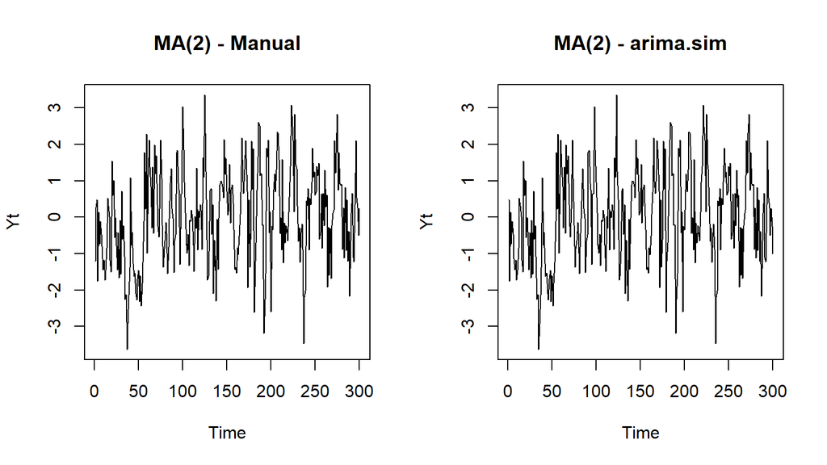

```r
par(mfrow = c(1, 2))
ts.plot(ma2_manual, main = "MA(2) - Manual", ylab = "Yt")
ts.plot(ma2_sim, main = "MA(2) - arima.sim", ylab = "Yt")
```

```r
par(mfrow = c(1, 1))
```

## 2.4 Plot ACF

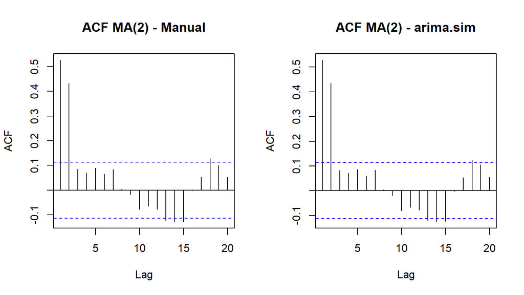

```r
par(mfrow = c(1, 2))
acf(ma2_manual, lag.max = 20, main = "ACF MA(2) - Manual")
acf(ma2_sim, lag.max = 20, main = "ACF MA(2) - arima.sim")
```

```r
par(mfrow = c(1, 1))
```

## 2.5 Plot PACF

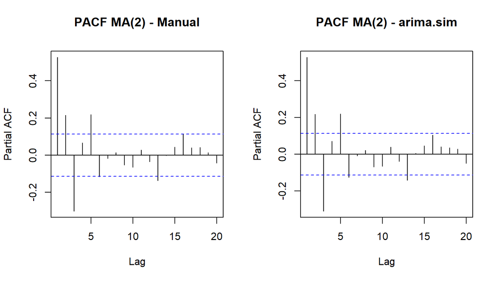

```r
par(mfrow = c(1, 2))
pacf(ma2_manual, lag.max = 20, main = "PACF MA(2) - Manual")
pacf(ma2_sim, lag.max = 20, main = "PACF MA(2) - arima.sim")
```

```r
par(mfrow = c(1, 1))
```

## 2.6 Plot EACF

```r
cat("EACF - Manual\n")
```

```
## EACF - Manual
```

```r
eacf(ma2_manual)
```

```
## AR/MA
##   0 1 2 3 4 5 6 7 8 9 10 11 12 13
## 0 x x o o o o o o o o o  o  x  x
## 1 x x x o o o o o o o o  o  o  o
## 2 x x x x o o o o o o o  o  o  o
## 3 x x x x x o o o o o o  o  o  o
## 4 x x x x x o o o o o o  o  o  o
## 5 x x x x x o x o o o o  o  o  o
## 6 x x x o x o o x o o o  o  o  o
## 7 x o x o x o o x o o o  o  o  o
```

```r
cat("\nEACF - arima.sim\n")
```

```
##
## EACF - arima.sim
```

```r
eacf(ma2_sim)
```

```
## AR/MA
##   0 1 2 3 4 5 6 7 8 9 10 11 12 13
## 0 x x o o o o o o o o o  o  x  x
## 1 x x x o o o o o o o o  o  o  o
## 2 x x x x o o o o o o o  o  o  o
## 3 x x x x o o o o o o o  o  o  o
## 4 x x x x o o o o o o o  o  o  o
## 5 x x o x x o x o o o o  o  o  o
## 6 o x o o x o o x o o o  o  o  o
## 7 x o x o x o o x o o o  o  o  o
```

## 2.7 Identifikasi Kestasioneran

Berdasarkan plot time series, data berfluktuasi di sekitar rataan yang konstan tanpa tren maupun perubahan ragam yang sistematis, sehingga data MA(2) yang dibangkitkan **stasioner** sejalan dengan sifat teoritis bahwa proses MA berorde hingga selalu stasioner. Pola ini juga didukung oleh plot ACF yang **cuts off** setelah lag ke-2 dan plot PACF yang **tails off**, sesuai karakteristik proses MA(2).

## 2.8 Scatterplot Antar Lag

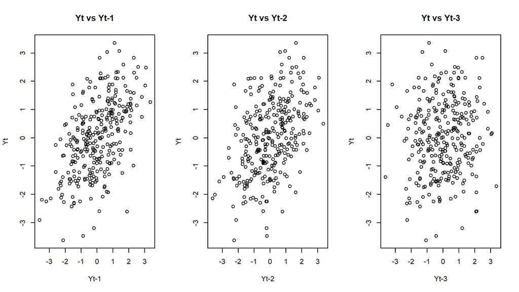

```r
par(mfrow = c(1, 3))

# Yt vs Yt-1
yt   <- ma2_manual[-1]
yt_1 <- ma2_manual[-n]
plot(yt_1, yt, xlab = "Yt-1", ylab = "Yt", main = "Yt vs Yt-1")

# Yt vs Yt-2
yt2   <- ma2_manual[-c(1, 2)]
yt_2  <- ma2_manual[-c(n - 1, n)]
plot(yt_2, yt2, xlab = "Yt-2", ylab = "Yt", main = "Yt vs Yt-2")

# Yt vs Yt-3
yt3   <- ma2_manual[-c(1, 2, 3)]
yt_3  <- ma2_manual[-c(n - 2, n - 1, n)]
plot(yt_3, yt3, xlab = "Yt-3", ylab = "Yt", main = "Yt vs Yt-3")
```

```r
par(mfrow = c(1, 1))
```

## 2.9 Autokorelasi: Empirik vs Teoritis

```r
rho1_teori_ma <- (theta1_ma + theta1_ma * theta2_ma) / (1 + theta1_ma^2 + theta2_ma^2)
rho2_teori_ma <- theta2_ma / (1 + theta1_ma^2 + theta2_ma^2)
rho3_teori_ma <- 0

rho_empirik_ma <- as.numeric(acf(ma2_manual, plot = FALSE, lag.max = 3)$acf[2:4])

hasil_ma2 <- data.frame(
  Lag      = 1:3,
  Empirik  = round(rho_empirik_ma, 4),
  Teoritis = round(c(rho1_teori_ma, rho2_teori_ma, rho3_teori_ma), 4)
)
kable(hasil_ma2, caption = "Autokorelasi MA(2): Empirik vs Teoritis")
```

Autokorelasi MA(2): Empirik vs Teoritis

[output not shown]

Autokorelasi empirik pada lag 1 dan 2 diharapkan mendekati nilai teoritisnya, sedangkan autokorelasi pada lag 3 dan seterusnya mendekati nol konsisten dengan sifat MA(2) yang memiliki *cut off* di lag ke-2.

# 3 Proses AR(2)

## 3.1 Landasan Teori

Proses AR(2) dituliskan sebagai:
$$Y_t = \phi_1 Y_{t-1} + \phi_2 Y_{t-2} + e_t$$

Untuk $\phi_1 = 0.5$ dan $\phi_2 = 0.2$, autokorelasi teoritis diperoleh dari persamaan Yule-Walker:
$$\rho_1 = \frac{\phi_1}{1-\phi_2}, \quad
\rho_2 = \phi_2 + \frac{\phi_1^2}{1-\phi_2}, \quad
\rho_k = \phi_1 \rho_{k-1} + \phi_2 \rho_{k-2} \; \text{untuk } k \ge 3$$

Proses AR(2) stasioner jika akar-akar polinomial karakteristik $1-\phi_1 B-\phi_2 B^2=0$ berada di luar lingkaran satuan (modulus > 1), atau secara ekivalen jika $\phi_1+\phi_2<1$, $\phi_2-\phi_1<1$, dan $|\phi_2|<1$.

```r
phi1_ar <- 0.5
phi2_ar <- 0.2

akar_ar2 <- polyroot(c(1, -phi1_ar, -phi2_ar))
Mod(akar_ar2)   # jika seluruhnya > 1, proses stasioner
```

```
## [1] 1.311738 3.811738
```

## 3.2 Pembangkitan Data

### 3.2.1 Manual (loop)

```r
set.seed(1234)
wn_ar <- rnorm(n)

ar2_manual <- numeric(n)
ar2_manual[1:2] <- wn_ar[1:2]   # nilai awal
for (i in 3:n) {
  ar2_manual[i] <- phi1_ar * ar2_manual[i - 1] + phi2_ar * ar2_manual[i - 2] + wn_ar[i]
}
ar2_manual <- ts(ar2_manual)
```

### 3.2.2 Dengan `arima.sim()`

```r
set.seed(1234)
ar2_sim <- arima.sim(model = list(order = c(2, 0, 0), ar = c(phi1_ar, phi2_ar)), n = n)
```

## 3.3 Plot Time Series

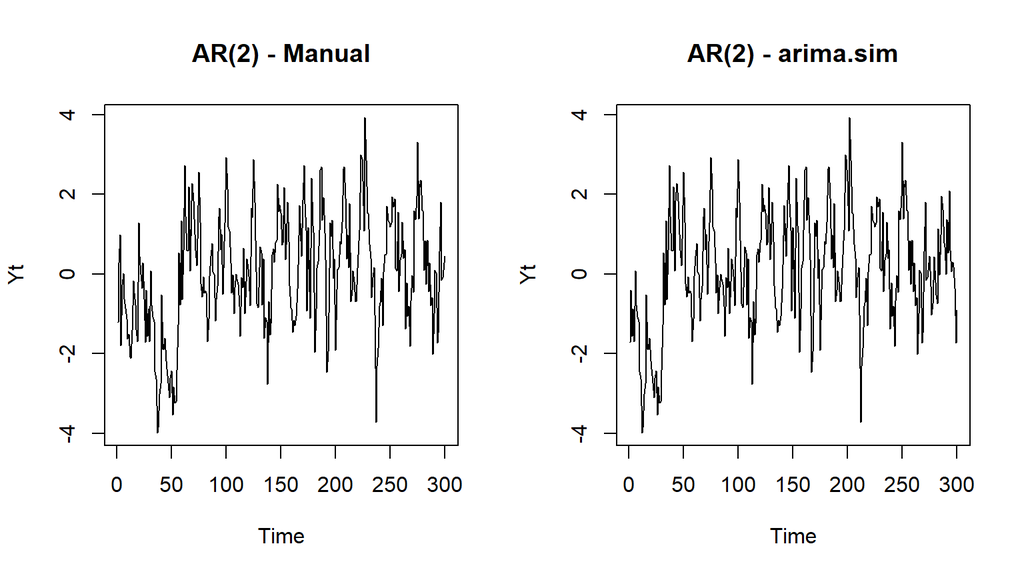

```r
par(mfrow = c(1, 2))
ts.plot(ar2_manual, main = "AR(2) - Manual", ylab = "Yt")
ts.plot(ar2_sim, main = "AR(2) - arima.sim", ylab = "Yt")
```

```r
par(mfrow = c(1, 1))
```

## 3.4 Plot ACF

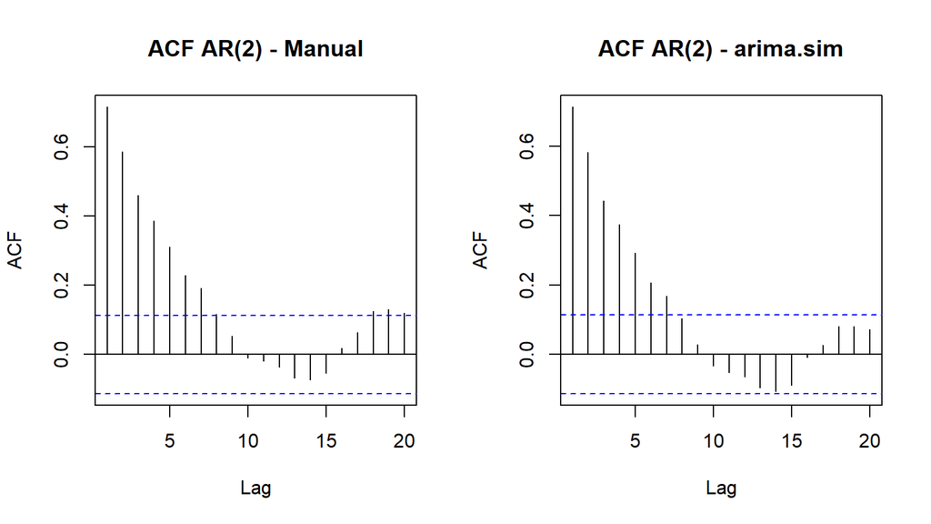

```r
par(mfrow = c(1, 2))
acf(ar2_manual, lag.max = 20, main = "ACF AR(2) - Manual")
acf(ar2_sim, lag.max = 20, main = "ACF AR(2) - arima.sim")
```

```r
par(mfrow = c(1, 1))
```

## 3.5 Plot PACF

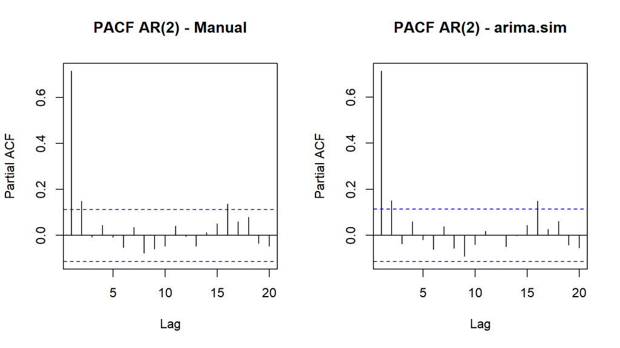

```r
par(mfrow = c(1, 2))
pacf(ar2_manual, lag.max = 20, main = "PACF AR(2) - Manual")
pacf(ar2_sim, lag.max = 20, main = "PACF AR(2) - arima.sim")
```

```r
par(mfrow = c(1, 1))
```

## 3.6 Plot EACF

```r
cat("EACF - Manual\n")
```

```
## EACF - Manual
```

```r
eacf(ar2_manual)
```

```
## AR/MA
##   0 1 2 3 4 5 6 7 8 9 10 11 12 13
## 0 x x x x x x x o o o o  o  o  o
## 1 x o o o o o o o o o o  o  o  o
## 2 o o o o o o o o o o o  o  o  o
## 3 x x o o o o o o o o o  o  o  o
## 4 x x o o o o o o o o o  o  o  o
## 5 x x o x o o x o o o o  o  o  o
## 6 x x x x o o o o o o o  o  o  o
## 7 x x x o x x o o o o o  o  o  o
```

```r
cat("\nEACF - arima.sim\n")
```

```
##
## EACF - arima.sim
```

```r
eacf(ar2_sim)
```

```
## AR/MA
##   0 1 2 3 4 5 6 7 8 9 10 11 12 13
## 0 x x x x x x x o o o o  o  o  o
## 1 x o o o o o o o o o o  o  o  o
## 2 x o o o o o o o o o o  o  o  o
## 3 x x o o o o o o o o o  o  o  o
## 4 x x o o o o o o o o o  o  o  o
## 5 x x x o o o o o o o o  o  o  o
## 6 x x x o o o o o o o o  o  o  o
## 7 x x x o x x o o o o o  o  o  o
```

## 3.7 Identifikasi Kestasioneran

Nilai modulus akar karakteristik pada bagian sebelumnya seluruhnya lebih dari satu, sehingga secara teoritis proses AR(2) ini **stasioner**. Hal tersebut juga tampak pada plot time series yang berfluktuasi konstan di sekitar rataan, plot ACF yang **tails off** membentuk pola menurun/gelombang sinus, serta plot PACF yang **cuts off** setelah lag ke-2 sesuai karakteristik teoritis proses AR(2).

## 3.8 Scatterplot Antar Lag

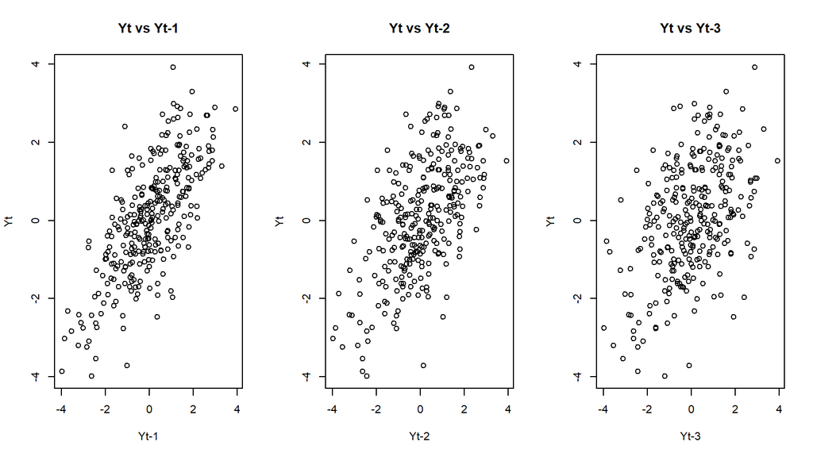

```r
par(mfrow = c(1, 3))

yt   <- ar2_manual[-1]
yt_1 <- ar2_manual[-n]
plot(yt_1, yt, xlab = "Yt-1", ylab = "Yt", main = "Yt vs Yt-1")

yt2  <- ar2_manual[-c(1, 2)]
yt_2 <- ar2_manual[-c(n - 1, n)]
plot(yt_2, yt2, xlab = "Yt-2", ylab = "Yt", main = "Yt vs Yt-2")

yt3  <- ar2_manual[-c(1, 2, 3)]
yt_3 <- ar2_manual[-c(n - 2, n - 1, n)]
plot(yt_3, yt3, xlab = "Yt-3", ylab = "Yt", main = "Yt vs Yt-3")
```

```r
par(mfrow = c(1, 1))
```

## 3.9 Autokorelasi: Empirik vs Teoritis

```r
rho1_teori_ar <- phi1_ar / (1 - phi2_ar)
rho2_teori_ar <- phi2_ar + (phi1_ar^2) / (1 - phi2_ar)
rho3_teori_ar <- phi1_ar * rho2_teori_ar + phi2_ar * rho1_teori_ar

rho_empirik_ar <- as.numeric(acf(ar2_manual, plot = FALSE, lag.max = 3)$acf[2:4])

hasil_ar2 <- data.frame(
  Lag      = 1:3,
  Empirik  = round(rho_empirik_ar, 4),
  Teoritis = round(c(rho1_teori_ar, rho2_teori_ar, rho3_teori_ar), 4)
)
kable(hasil_ar2, caption = "Autokorelasi AR(2): Empirik vs Teoritis")
```

Autokorelasi AR(2): Empirik vs Teoritis

[output not shown]

Berbeda dengan MA(2), autokorelasi pada AR(2) tidak langsung terpotong tetapi menurun secara bertahap (tails off) mengikuti persamaan rekursif Yule-Walker di atas.

# 4 Proses ARMA(2,2)

## 4.1 Landasan Teori

Proses ARMA(2,2) dituliskan sebagai:
$$Y_t = \phi_1 Y_{t-1} + \phi_2 Y_{t-2} + e_t + \theta_1 e_{t-1} +
\theta_2 e_{t-2}$$

Bagian AR menentukan kestasioneran (syarat sama seperti AR(2)) dan bagian MA menentukan keterbalikan (*invertibility*, syarat serupa berlaku untuk $\theta_1,\theta_2$). Karena bentuk fungsi autokorelasi teoritis ARMA(p,q) melibatkan kombinasi komponen AR dan MA yang cukup rumit untuk diturunkan secara manual pada orde (2,2), autokorelasi teoritisnya dihitung menggunakan fungsi bawaan R `ARMAacf()` yang menyelesaikan persamaan Yule-Walker umum untuk proses ARMA.

```r
phi1_arma   <- 0.5
phi2_arma   <- 0.2
theta1_arma <- 0.4
theta2_arma <- 0.6

# Cek kestasioneran (bagian AR) dan keterbalikan (bagian MA)
akar_ar_arma <- polyroot(c(1, -phi1_arma, -phi2_arma))
akar_ma_arma <- polyroot(c(1, theta1_arma, theta2_arma))
Mod(akar_ar_arma)   # kestasioneran: seluruhnya > 1
```

```
## [1] 1.311738 3.811738
```

```r
Mod(akar_ma_arma)   # keterbalikan: seluruhnya > 1
```

```
## [1] 1.290994 1.290994
```

## 4.2 Pembangkitan Data

### 4.2.1 Manual (loop)

```r
set.seed(1234)
wn_arma <- rnorm(n)

arma22_manual <- numeric(n)
arma22_manual[1:2] <- wn_arma[1:2]   # nilai awal
for (i in 3:n) {
  arma22_manual[i] <- phi1_arma * arma22_manual[i - 1] +
                       phi2_arma * arma22_manual[i - 2] +
                       wn_arma[i] +
                       theta1_arma * wn_arma[i - 1] +
                       theta2_arma * wn_arma[i - 2]
}
arma22_manual <- ts(arma22_manual)
```

### 4.2.2 Dengan `arima.sim()`

```r
set.seed(1234)
arma22_sim <- arima.sim(
  model = list(order = c(2, 0, 2),
               ar = c(phi1_arma, phi2_arma),
               ma = c(theta1_arma, theta2_arma)),
  n = n
)
```

## 4.3 Plot Time Series

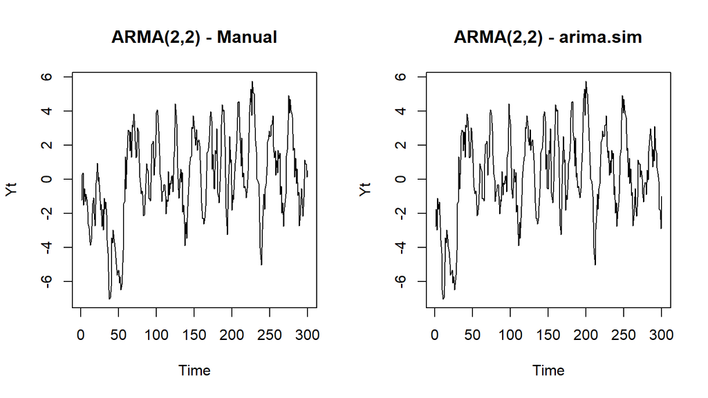

```r
par(mfrow = c(1, 2))
ts.plot(arma22_manual, main = "ARMA(2,2) - Manual", ylab = "Yt")
ts.plot(arma22_sim, main = "ARMA(2,2) - arima.sim", ylab = "Yt")
```

```r
par(mfrow = c(1, 1))
```

## 4.4 Plot ACF

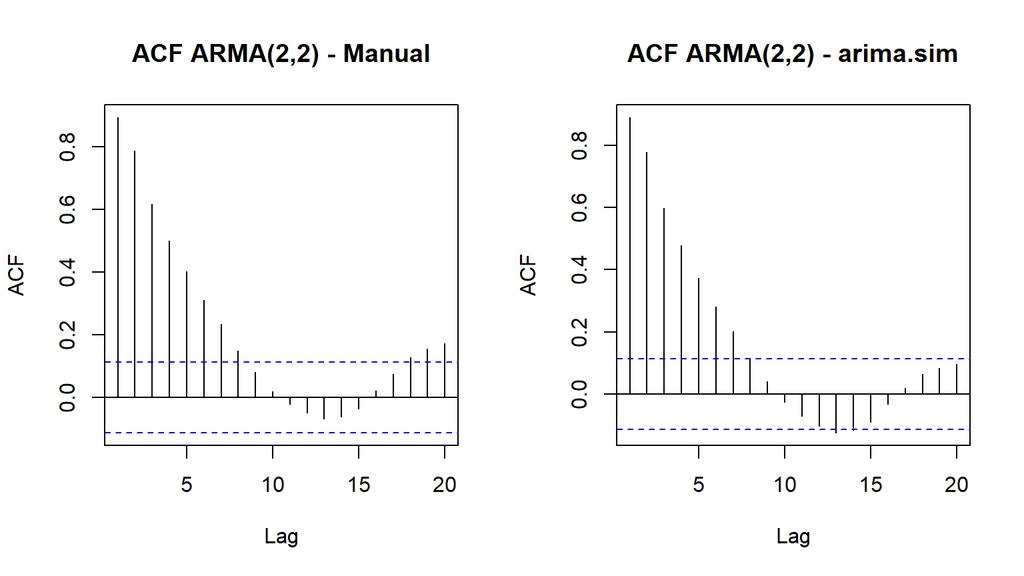

```r
par(mfrow = c(1, 2))
acf(arma22_manual, lag.max = 20, main = "ACF ARMA(2,2) - Manual")
acf(arma22_sim, lag.max = 20, main = "ACF ARMA(2,2) - arima.sim")
```

```r
par(mfrow = c(1, 1))
```

## 4.5 Plot PACF

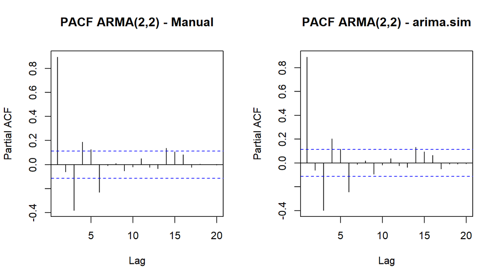

```r
par(mfrow = c(1, 2))
pacf(arma22_manual, lag.max = 20, main = "PACF ARMA(2,2) - Manual")
pacf(arma22_sim, lag.max = 20, main = "PACF ARMA(2,2) - arima.sim")
```

```r
par(mfrow = c(1, 1))
```

## 4.6 Plot EACF

```r
cat("EACF - Manual\n")
```

```
## EACF - Manual
```

```r
eacf(arma22_manual)
```

```
## AR/MA
##   0 1 2 3 4 5 6 7 8 9 10 11 12 13
## 0 x x x x x x x x o o o  o  o  o
## 1 o x o o o o x o o o o  o  o  o
## 2 x x o o o o x o o o o  o  o  o
## 3 x x o x o o x o o o o  o  o  o
## 4 x x x x o o x o o o o  o  o  o
## 5 x x x x x x x o o o o  o  o  o
## 6 o o x o x x o o o o o  o  o  o
## 7 o o x o x x o x o o o  o  o  o
```

```r
cat("\nEACF - arima.sim\n")
```

```
##
## EACF - arima.sim
```

```r
eacf(arma22_sim)
```

```
## AR/MA
##   0 1 2 3 4 5 6 7 8 9 10 11 12 13
## 0 x x x x x x x o o o o  o  x  o
## 1 o x o o o o x o o o o  o  o  o
## 2 x x o o o o o o o o o  o  o  o
## 3 x x x x o o o o o o o  o  o  o
## 4 x x x x o o o o o o o  o  o  o
## 5 x x x x x x x o o o o  o  o  o
## 6 o o x o x x o o o o o  o  o  o
## 7 x o x x x x o x o o o  o  o  o
```

## 4.7 Identifikasi Kestasioneran

Modulus akar karakteristik bagian AR seluruhnya lebih dari satu sehingga proses **stasioner**, dan modulus akar bagian MA juga lebih dari satu sehingga proses **invertible**. Pada plot time series data berfluktuasi konstan di sekitar rataan, sedangkan plot ACF maupun PACF sama-sama **tails off** ciri khas proses campuran ARMA yang membedakannya dari AR maupun MA murni.

## 4.8 Scatterplot Antar Lag

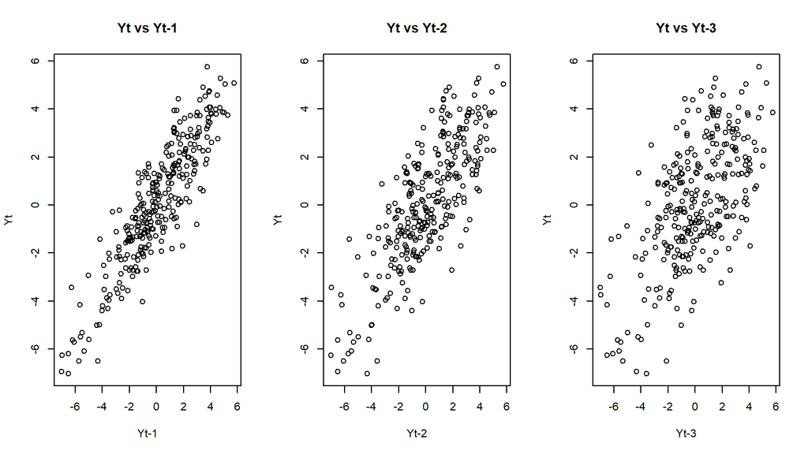

```r
par(mfrow = c(1, 3))

yt   <- arma22_manual[-1]
yt_1 <- arma22_manual[-n]
plot(yt_1, yt, xlab = "Yt-1", ylab = "Yt", main = "Yt vs Yt-1")

yt2  <- arma22_manual[-c(1, 2)]
yt_2 <- arma22_manual[-c(n - 1, n)]
plot(yt_2, yt2, xlab = "Yt-2", ylab = "Yt", main = "Yt vs Yt-2")

yt3  <- arma22_manual[-c(1, 2, 3)]
yt_3 <- arma22_manual[-c(n - 2, n - 1, n)]
plot(yt_3, yt3, xlab = "Yt-3", ylab = "Yt", main = "Yt vs Yt-3")
```

```r
par(mfrow = c(1, 1))
```

## 4.9 Autokorelasi: Empirik vs Teoritis

```r
rho_teori_arma <- ARMAacf(ar = c(phi1_arma, phi2_arma),
                           ma = c(theta1_arma, theta2_arma),
                           lag.max = 3)[-1]

rho_empirik_arma <- as.numeric(acf(arma22_manual, plot = FALSE, lag.max = 3)$acf[2:4])

hasil_arma22 <- data.frame(
  Lag      = 1:3,
  Empirik  = round(rho_empirik_arma, 4),
  Teoritis = round(as.numeric(rho_teori_arma), 4)
)
kable(hasil_arma22, caption = "Autokorelasi ARMA(2,2): Empirik vs Teoritis")
```

Autokorelasi ARMA(2,2): Empirik vs Teoritis

[output not shown]

Sejalan dengan sifat teoritis ARMA(p,q), autokorelasi menurun secara eksponensial (tails off) tanpa terpotong tegas seperti pada proses MA murni.

# 5 Rangkuman

```r
rangkuman <- data.frame(
  Proses     = c("MA(2)", "AR(2)", "ARMA(2,2)"),
  Plot_ACF   = c("Cuts off lag-2", "Tails off", "Tails off"),
  Plot_PACF  = c("Tails off", "Cuts off lag-2", "Tails off"),
  Stasioner  = c("Selalu stasioner", "Stasioner (cek akar)", "Stasioner & invertible (cek akar)")
)
kable(rangkuman, caption = "Ringkasan karakteristik ketiga proses")
```

Ringkasan karakteristik ketiga proses

| Proses | Plot_ACF | Plot_PACF | Stasioner |
| --- | --- | --- | --- |
| MA(2) | Cuts off lag-2 | Tails off | Selalu stasioner |
| AR(2) | Tails off | Cuts off lag-2 | Stasioner (cek akar) |
| ARMA(2,2) | Tails off | Tails off | Stasioner & invertible (cek akar) |

Ketiga proses menunjukkan pola ACF/PACF yang konsisten dengan teori: MA(2) memotong tegas di lag ke-2, AR(2) memotong tegas pada PACF di lag ke-2, dan ARMA(2,2) meluruh (tails off) pada kedua plot hasil bangkitan manual dan `arima.sim()` juga menunjukkan pola visual yang sebanding, sementara autokorelasi empirik mendekati nilai teoritis pada setiap kasus.